# IODS course project

Janne Kirjasniemi

# Introduction to open data science

## A short description

Introduction to open data science is a course about the tools, methods and best practices of scientific research and I suppose research in general using data science and open sources. I expect to practice my skill in R and get to know how to use Github and R Markdown, which seem like valuable tools for this purpose.

https://jknyemy.github.io/IODS-project/

# Chapter 2

# Chapter three

### Of student’s and alcohol

First of all, the student’s sex is worth looking at as an extra information:

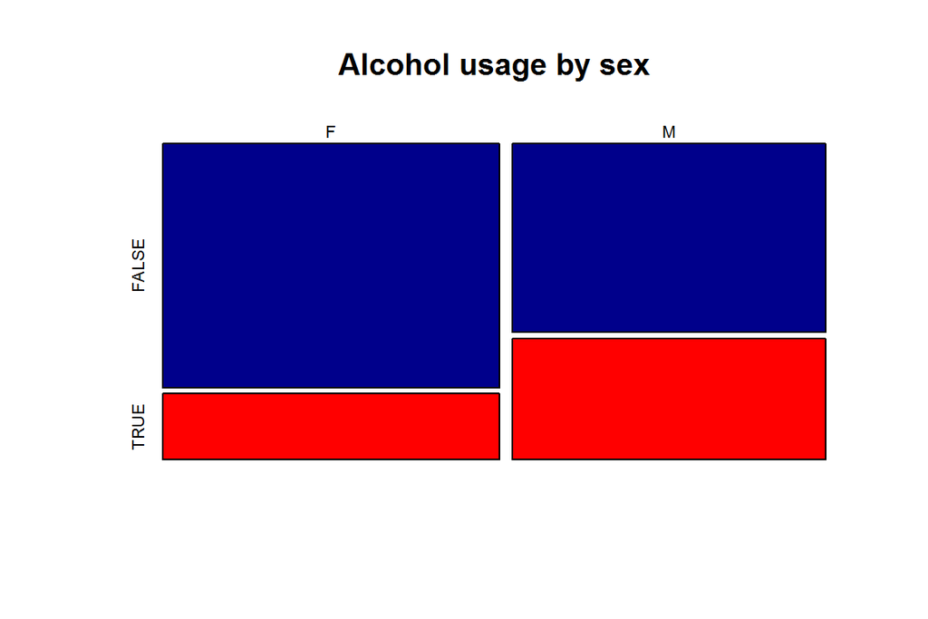

```r
studen_alc <- read.csv2("C:/Users/Janne/Documents/GitHub/IODS-project/data/student_alc.csv")
sukup <- table(studen_alc$sex, studen_alc$high_use)
plot(sukup, main = ("Alcohol usage by sex"), col=c("darkblue", "red"))
```

Of this we can surmise, that while there is a higher incidence of high alcohol consumption among males, there is still ample use among the females, but only one in four females fall under high use, while in males this proportion is two out five.

#### Free time and alcohol consumption

First of all romance. I chose this variable to find out, whether a romantic commitment lessens the occurence of high alcohol use.

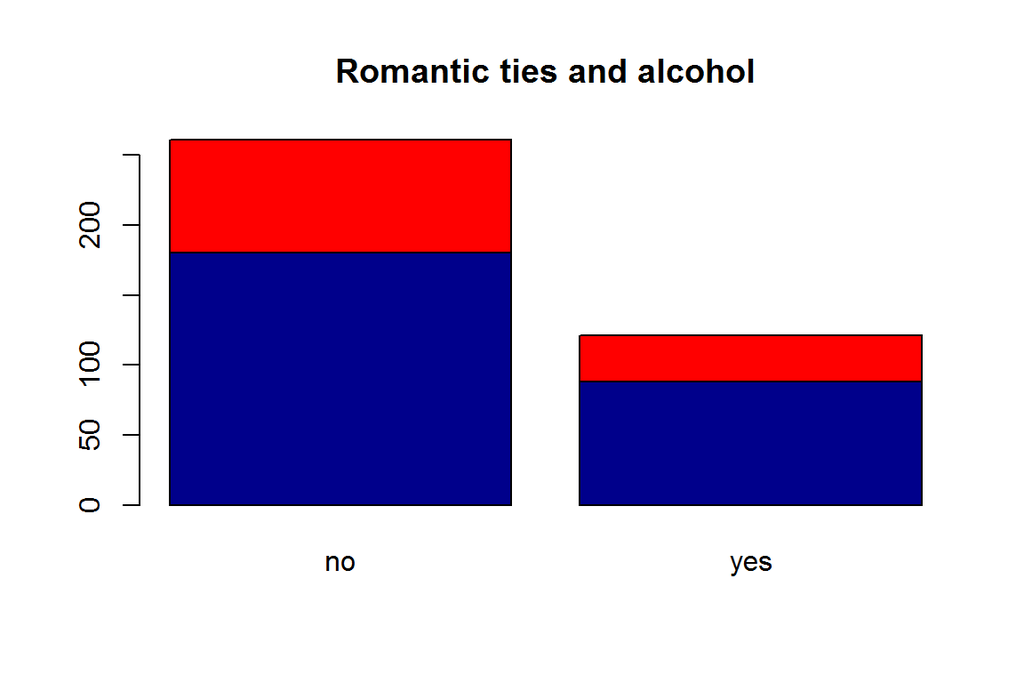

```r
rom_alc <- table(studen_alc$high_use, studen_alc$romantic)
barplot(rom_alc, col=c("darkblue", "red" ), legend = rownames(studen_alc$romantic), main=("Romantic ties and alcohol"))
```

# Chapter 4

## Housing values in the Suburbs of Boston

The Boston dataset in the MASS package details the different conditions in 506 Boston suburbs through 14 variables ranging from per capita crime rate to access to highways and distance to employment centres and other variables relating to a suburbs attributes as a place to live. Here is a basic rundown of the general properties of the variables:

```r
library(MASS)
library(dplyr)
library(ggplot2)
library(corrplot)
data("Boston")
```

```r
summary(Boston)
```

```
##       crim                zn             indus            chas
##  Min.   : 0.00632   Min.   :  0.00   Min.   : 0.46   Min.   :0.00000
##  1st Qu.: 0.08204   1st Qu.:  0.00   1st Qu.: 5.19   1st Qu.:0.00000
##  Median : 0.25651   Median :  0.00   Median : 9.69   Median :0.00000
##  Mean   : 3.61352   Mean   : 11.36   Mean   :11.14   Mean   :0.06917
##  3rd Qu.: 3.67708   3rd Qu.: 12.50   3rd Qu.:18.10   3rd Qu.:0.00000
##  Max.   :88.97620   Max.   :100.00   Max.   :27.74   Max.   :1.00000
##       nox               rm             age              dis
##  Min.   :0.3850   Min.   :3.561   Min.   :  2.90   Min.   : 1.130
##  1st Qu.:0.4490   1st Qu.:5.886   1st Qu.: 45.02   1st Qu.: 2.100
##  Median :0.5380   Median :6.208   Median : 77.50   Median : 3.207
##  Mean   :0.5547   Mean   :6.285   Mean   : 68.57   Mean   : 3.795
##  3rd Qu.:0.6240   3rd Qu.:6.623   3rd Qu.: 94.08   3rd Qu.: 5.188
##  Max.   :0.8710   Max.   :8.780   Max.   :100.00   Max.   :12.127
##       rad              tax           ptratio          black
##  Min.   : 1.000   Min.   :187.0   Min.   :12.60   Min.   :  0.32
##  1st Qu.: 4.000   1st Qu.:279.0   1st Qu.:17.40   1st Qu.:375.38
##  Median : 5.000   Median :330.0   Median :19.05   Median :391.44
##  Mean   : 9.549   Mean   :408.2   Mean   :18.46   Mean   :356.67
##  3rd Qu.:24.000   3rd Qu.:666.0   3rd Qu.:20.20   3rd Qu.:396.23
##  Max.   :24.000   Max.   :711.0   Max.   :22.00   Max.   :396.90
##      lstat            medv
##  Min.   : 1.73   Min.   : 5.00
##  1st Qu.: 6.95   1st Qu.:17.02
##  Median :11.36   Median :21.20
##  Mean   :12.65   Mean   :22.53
##  3rd Qu.:16.95   3rd Qu.:25.00
##  Max.   :37.97   Max.   :50.00
```

It needs to be pointed out that chas is a binomial variable, telling whether the area in question is on the Charles River. Next, a correlation matrix of the variables, where blue indicates a positive and red a negative correlation between variables(where the depth of the colour and the size of the ball indicates the strength of the correlation):

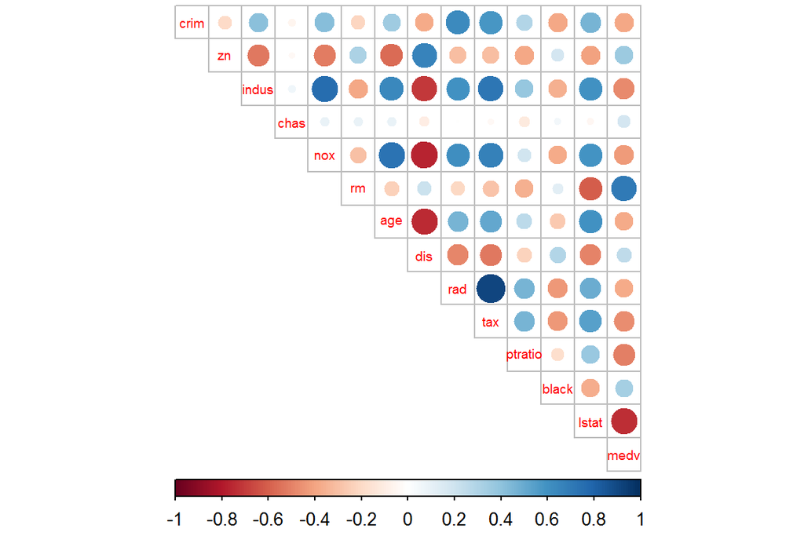

```r
#Making a correlation matrix of variables
cor_matrix<-cor(Boston) %>% round(digits = 2)
corrplot(cor_matrix, method="circle", type = "upper", cl.pos = "b", tl.pos = "d", tl.cex = 0.6)
```

Here, for example we can see that there is some correlation between per capita crime rate(crim) and the ratio of non-retail businesses in a suburb(indus) and also with nitrogen oxide concentration levels in the air(nox). And a strong negative correlation between ages of the building(age) and distance to employment centres(dis), which would imply that the higher the age of the building, the nearer it is to employment. Also, there is a positive correlation between crime rate and age of the buidings. All of these are to be expected of a city that has grown outside from a city(or colonial town) centre, as Boston has.

In the following are the boxplots of the variables, omitting the variable chas, which is a binomial variable. As can be seen from the summary numbers earlier, the different distributions of variables are in very different scales, so to allow comparison, the data has been scaled to the standard normal distribution:

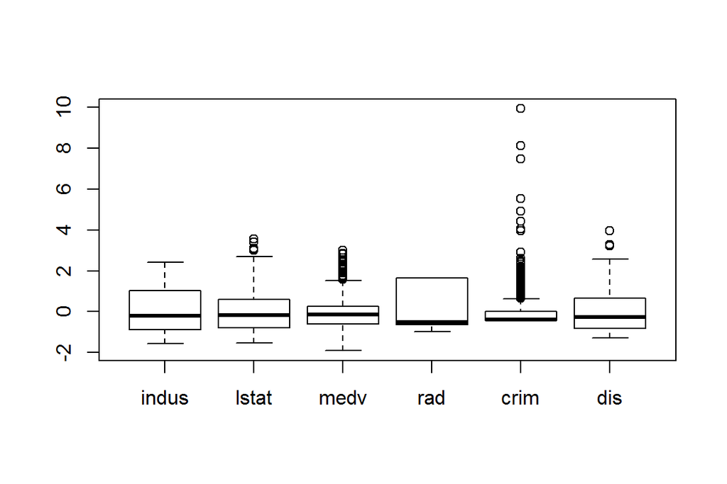

```r
#Standardizing the Boston dataset
boston_scaled <- scale(Boston)
boston_scaled <- as.data.frame(boston_scaled)
#Making the boxplots
bosvar1 <- c("indus", "lstat", "medv", "rad","crim", "dis")
bosvar2 <- c("black", "tax", "age", "rm","ptratio", "zn", "nox")
boston_m1 <- select(boston_scaled, one_of(bosvar1))
boxplot(boston_m1)
```

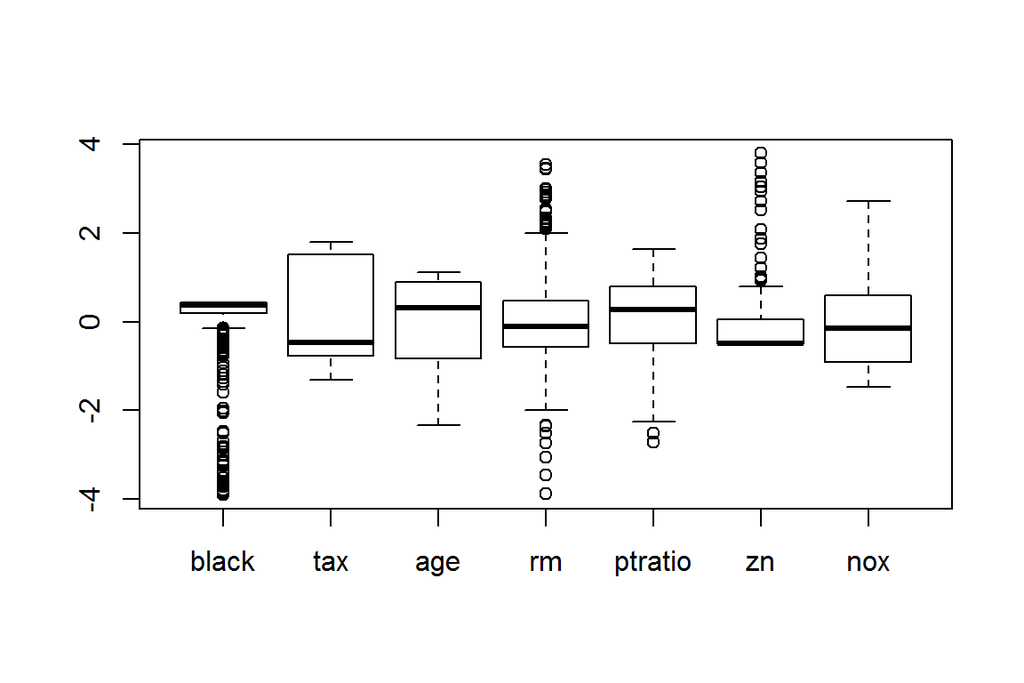

```r
boston_m2 <- select(boston_scaled, one_of(bosvar2))
boxplot(boston_m2)
```

As can be observed, the distributions are quite varied, with for example the proportion of african-american population being quite densely gathered above the mean, but having lots of outliers with smaller proportions, the same applying to zn, which is the proportion of large residential lots, where the mass of the distribution is gathered around the mean, with outliers having larger proportions. However, these outliers don’t matter much, which can be seen for example that the variable black is still skewed above the mean.

Here are the summaries of the scaled data:

```r
summary(boston_scaled)
```

```
##       crim                 zn               indus
##  Min.   :-0.419367   Min.   :-0.48724   Min.   :-1.5563
##  1st Qu.:-0.410563   1st Qu.:-0.48724   1st Qu.:-0.8668
##  Median :-0.390280   Median :-0.48724   Median :-0.2109
##  Mean   : 0.000000   Mean   : 0.00000   Mean   : 0.0000
##  3rd Qu.: 0.007389   3rd Qu.: 0.04872   3rd Qu.: 1.0150
##  Max.   : 9.924110   Max.   : 3.80047   Max.   : 2.4202
##       chas              nox                rm               age
##  Min.   :-0.2723   Min.   :-1.4644   Min.   :-3.8764   Min.   :-2.3331
##  1st Qu.:-0.2723   1st Qu.:-0.9121   1st Qu.:-0.5681   1st Qu.:-0.8366
##  Median :-0.2723   Median :-0.1441   Median :-0.1084   Median : 0.3171
##  Mean   : 0.0000   Mean   : 0.0000   Mean   : 0.0000   Mean   : 0.0000
##  3rd Qu.:-0.2723   3rd Qu.: 0.5981   3rd Qu.: 0.4823   3rd Qu.: 0.9059
##  Max.   : 3.6648   Max.   : 2.7296   Max.   : 3.5515   Max.   : 1.1164
##       dis               rad               tax             ptratio
##  Min.   :-1.2658   Min.   :-0.9819   Min.   :-1.3127   Min.   :-2.7047
##  1st Qu.:-0.8049   1st Qu.:-0.6373   1st Qu.:-0.7668   1st Qu.:-0.4876
##  Median :-0.2790   Median :-0.5225   Median :-0.4642   Median : 0.2746
##  Mean   : 0.0000   Mean   : 0.0000   Mean   : 0.0000   Mean   : 0.0000
##  3rd Qu.: 0.6617   3rd Qu.: 1.6596   3rd Qu.: 1.5294   3rd Qu.: 0.8058
##  Max.   : 3.9566   Max.   : 1.6596   Max.   : 1.7964   Max.   : 1.6372
##      black             lstat              medv
##  Min.   :-3.9033   Min.   :-1.5296   Min.   :-1.9063
##  1st Qu.: 0.2049   1st Qu.:-0.7986   1st Qu.:-0.5989
##  Median : 0.3808   Median :-0.1811   Median :-0.1449
##  Mean   : 0.0000   Mean   : 0.0000   Mean   : 0.0000
##  3rd Qu.: 0.4332   3rd Qu.: 0.6024   3rd Qu.: 0.2683
##  Max.   : 0.4406   Max.   : 3.5453   Max.   : 2.9865
```

```r
#Evolving the crim variable into a categorical variable by quantiles
scaled_crim <- boston_scaled$crim
bins <- quantile(scaled_crim)
crime_cat <- cut(scaled_crim, breaks = bins, include.lowest = TRUE, label = c("low", "med_low", "med_high", "high"))
boston_scaled$crim <- crime_cat
#Producing a train set and a test set
n <- nrow(Boston)
ind <- sample(n,  size = n * 0.8)
train <- boston_scaled[ind,]
test <- boston_scaled[-ind,]
#Saving the crim variable from test and then removing it from it.
correct_classes <- test$crim
test <- dplyr::select(test, -crim)
```

Using linear discriminant analysis on the scaled data with crime rate as a target variable against the other variables and making a biplot of the results gives us the following:

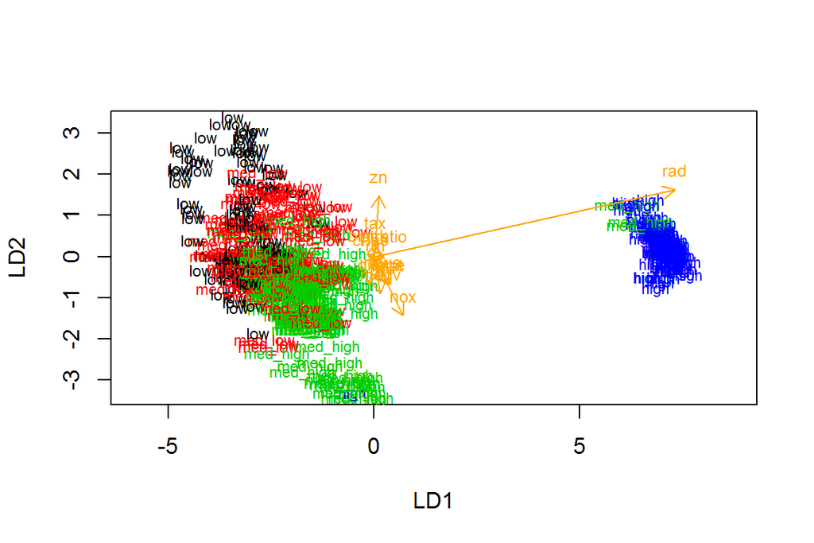

```r
#Fitting the linear discriminant analysis
lda.fit <- lda(crim ~ ., data = train)
#A function for arrows for the biplot
lda.arrows <- function(x, myscale = 1, arrow_heads = 0.1, color = "orange", tex = 0.75, choices = c(1,2)){
  heads <- coef(x)
  arrows(x0 = 0, y0 = 0,
         x1 = myscale * heads[,choices[1]],
         y1 = myscale * heads[,choices[2]], col=color, length = arrow_heads)
  text(myscale * heads[,choices], labels = row.names(heads),
       cex = tex, col=color, pos=3)
}
#A numeric vector to paint the picture by
classes <- as.numeric(train$crim)
#The biplot with arrows included
plot(lda.fit, dimen = 2, col = classes, pch=classes)
lda.arrows(lda.fit, myscale = 2)
```

From the biplot we can see, that high crime rate is clustered separately from the rest, but the rest, while overlapping, are still clustered so that on can discern the classes from it.The arrows show the impact of different variables on the model. While the presence of pollution(nox) and the rate of large properties(zn) have some impact, curiously it seems that in the case of high crime rate, the accessibility to radial highways(rad) has a very strong impact.

Next we’ll see, how the model handles predicting.

```r
#Prediction and a table of results
lda.pred <- predict(lda.fit, newdata = test)
table(correct = correct_classes, predicted = lda.pred$class)
```

```
##           predicted
## correct    low med_low med_high high
##   low       13       9        2    0
##   med_low    3      19        5    0
##   med_high   0       4       20    3
##   high       0       0        0   24
```

Next we’ll se what sort of clusters are to be found from the standardized Boston dataset:

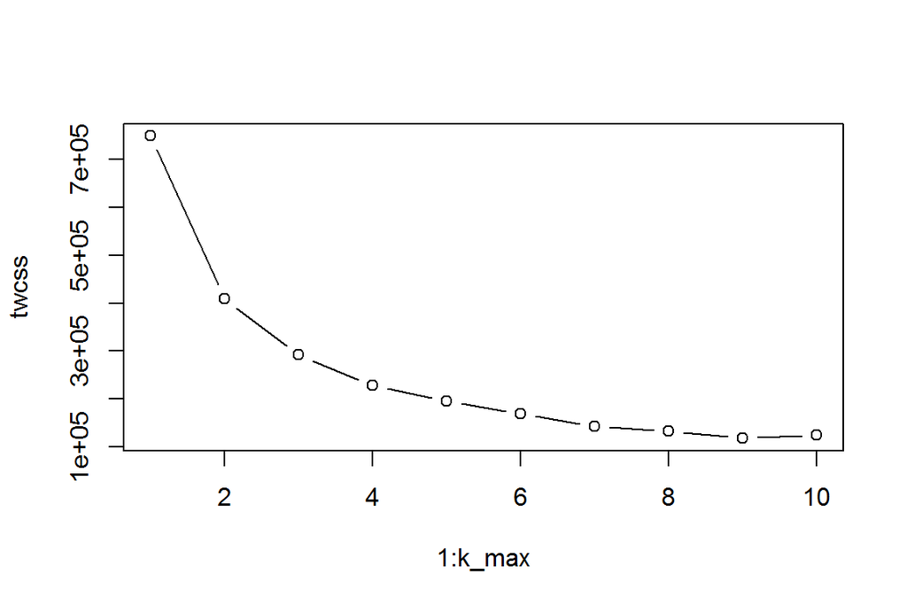

```r
#Getting the euclidean distance matrix from scaled standardized values so they are comparable
data(Boston)
boston_rescale <- scale(Boston)
dist_bost <- dist(boston_rescale)
#Finding the optimal number of clusters
k_max <- 10
twcss <- sapply(1:k_max, function(k){kmeans(dist_bost, k)$tot.withinss})
plot(1:k_max, twcss, type='b')
```

As the function for within cluster sum of squares drops quite dramatically toeither two or four clusters, we will pick two, to see if there are some clear results. Next we will calculate the K-means, show a table of them and visualize the result:

```r
km <-kmeans(dist_bost, centers = 2)
table(km$cluster)
```

```
##
##   1   2
## 179 327
```

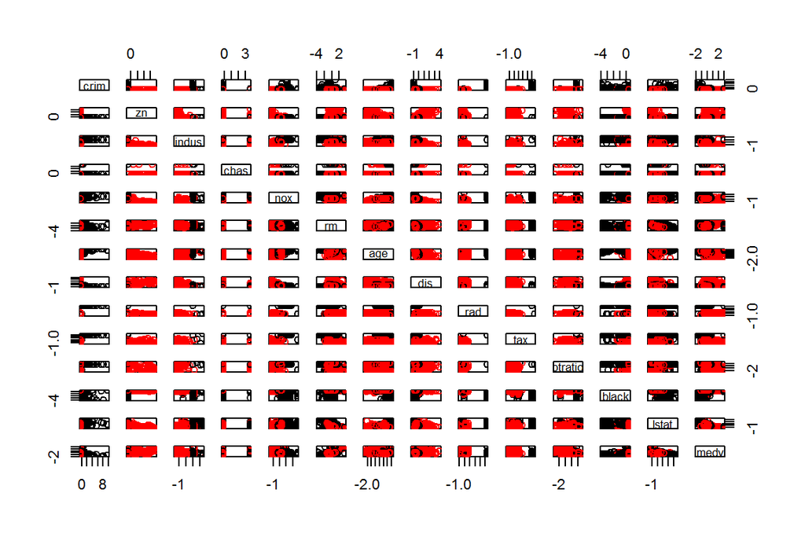

```r
pairs(boston_rescale, col = km$cluster)
```

So, dividing the observations into two clusters seems to yield some results and it seems that the clearest cluster is the one holding the variables for crime rate and the rate of the african american population. With three clusters the result is similar:

```r
km <-kmeans(dist_bost, centers = 3)
table(km$cluster)
```

```
##
##   1   2   3
## 306  70 130
```

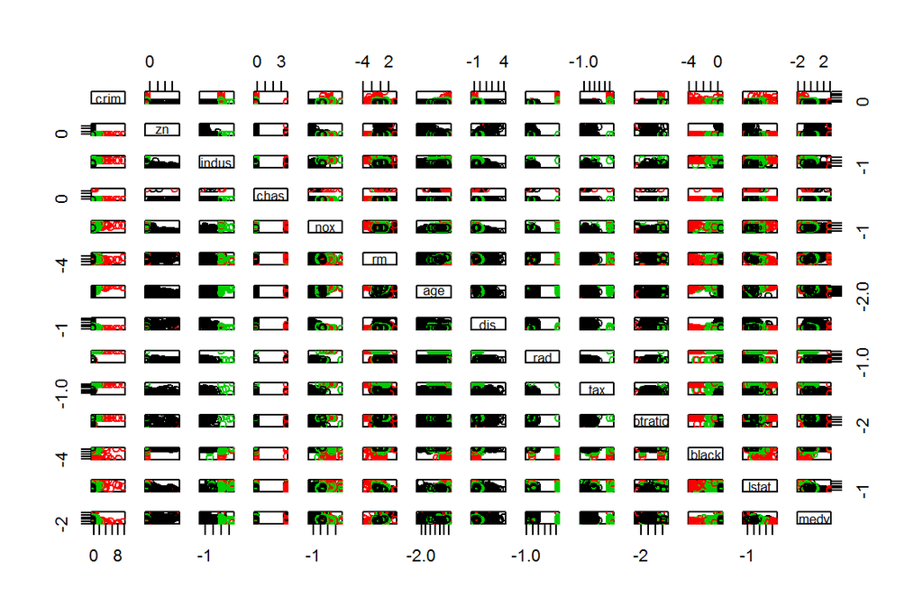

```r
pairs(boston_rescale, col = km$cluster)
```

# Chapter 5

## Varieties of development in the world

The following text analyses some variables taken from the UN Human Development Index. The eight variables chosen describe conditions relating to health, wealth, knowledge and the gender proportions in 155 countries of the world, where some countries are missing because of missing data from said countries. Here is a summary of the different variables:

```r
human <- read.table("C:/Users/Janne/Documents/GitHub/IODS-project/data/human.txt", sep  ="", header = T)
summary(human)
```

```
##     Edu2.FM          Labo.FM          Edu.Exp         Life.Exp
##  Min.   :0.1717   Min.   :0.1857   Min.   : 5.40   Min.   :49.00
##  1st Qu.:0.7264   1st Qu.:0.5984   1st Qu.:11.25   1st Qu.:66.30
##  Median :0.9375   Median :0.7535   Median :13.50   Median :74.20
##  Mean   :0.8529   Mean   :0.7074   Mean   :13.18   Mean   :71.65
##  3rd Qu.:0.9968   3rd Qu.:0.8535   3rd Qu.:15.20   3rd Qu.:77.25
##  Max.   :1.4967   Max.   :1.0380   Max.   :20.20   Max.   :83.50
##       GNI            Mat.Mor         Ado.Birth         Parli.F
##  Min.   :   581   Min.   :   1.0   Min.   :  0.60   Min.   : 0.00
##  1st Qu.:  4198   1st Qu.:  11.5   1st Qu.: 12.65   1st Qu.:12.40
##  Median : 12040   Median :  49.0   Median : 33.60   Median :19.30
##  Mean   : 17628   Mean   : 149.1   Mean   : 47.16   Mean   :20.91
##  3rd Qu.: 24512   3rd Qu.: 190.0   3rd Qu.: 71.95   3rd Qu.:27.95
##  Max.   :123124   Max.   :1100.0   Max.   :204.80   Max.   :57.50
```

Now, for example the variable Edu2.FM is the proportion of women having a secondary education divided by the proportion of men having the same. Labo.FM is the proportion of women in the labour force divided by the male proprtion. Interestingly the median values, which are perhaps more illuminating in this context, for the variables in question are quite high. The median of Edu2.FM is over 0.9. But the variance of the distribution is quite wide in these two variables, as it is in all variables. Now, observing the overview of the dataset and correlations between variables:

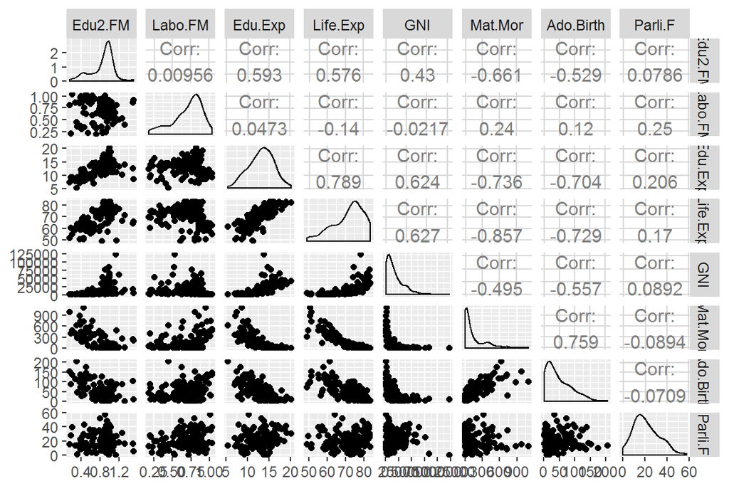

```r
ggpairs(human)
```

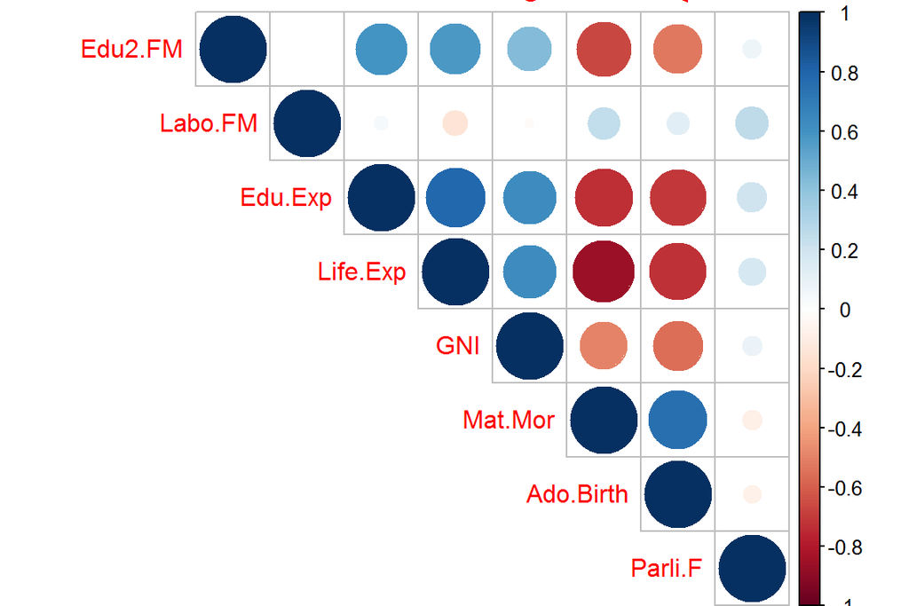

```r
corrplot(cor(human), type="upper")
```

Both of these visualizations seem to indicate a negative correlation between gross national income(GNI) on the other hand and maternal mortality rate and adolescence birth rate on the other hand. And a strong negative correlation between the rate of female education and both maternal mortality rate and adolescence birth rate. Interestingly, the correlation visualization suggests a weak positive correlation between women’s participation in the labour force and no correlation at all between GNI and labour participation. From the scatterplots of the variables one can see, that labour participation is much more evenly distributed and one could indiuce from this, that very bad conditions often force people to work for sustenance even in situations, where it can have negative effects in child mortality for example.

Now a principal component analysis on the dataset, using singular value decomposition, with a biplot visualization of the results:

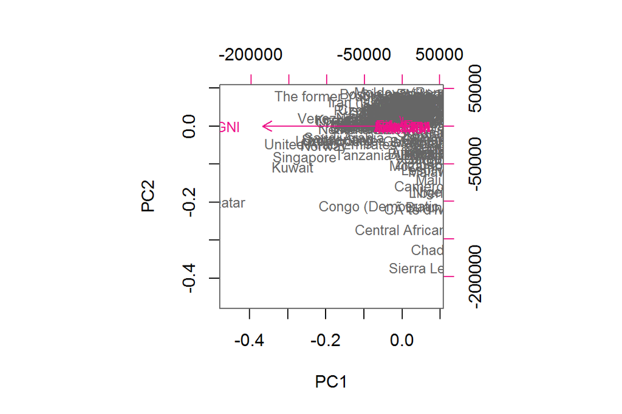

```r
pca_human <- prcomp(human)
biplot(pca_human, choices = 1:2, cex = c(0.8, .8), col = c("grey40", "deeppink2"))
```

```r
pca_human
```

```
## Standard deviations:
## [1] 1.854416e+04 1.855219e+02 2.518701e+01 1.145441e+01 3.766241e+00
## [6] 1.565912e+00 1.912052e-01 1.591112e-01
##
## Rotation:
##                     PC1           PC2           PC3           PC4
## Edu2.FM   -5.607472e-06  0.0006713951 -3.412027e-05 -2.736326e-04
## Labo.FM    2.331945e-07 -0.0002819357  5.302884e-04 -4.692578e-03
## Edu.Exp   -9.562910e-05  0.0075529759  1.427664e-02 -3.313505e-02
## Life.Exp  -2.815823e-04  0.0283150248  1.294971e-02 -6.752684e-02
## GNI       -9.999832e-01 -0.0057723054 -5.156742e-04  4.932889e-05
## Mat.Mor    5.655734e-03 -0.9916320120  1.260302e-01 -6.100534e-03
## Ado.Birth  1.233961e-03 -0.1255502723 -9.918113e-01  5.301595e-03
## Parli.F   -5.526460e-05  0.0032317269 -7.398331e-03 -9.971232e-01
##                     PC5           PC6           PC7           PC8
## Edu2.FM   -0.0022935252  2.180183e-02  6.998623e-01  7.139410e-01
## Labo.FM    0.0022190154  3.264423e-02  7.132267e-01 -7.001533e-01
## Edu.Exp    0.1431180282  9.882477e-01 -3.826887e-02  7.776451e-03
## Life.Exp   0.9865644425 -1.453515e-01  5.380452e-03  2.281723e-03
## GNI       -0.0001135863 -2.711698e-05 -8.075191e-07 -1.176762e-06
## Mat.Mor    0.0266373214  1.695203e-03  1.355518e-04  8.371934e-04
## Ado.Birth  0.0188618600  1.273198e-02 -8.641234e-05 -1.707885e-04
## Parli.F   -0.0716401914 -2.309896e-02 -2.642548e-03  2.680113e-03
```

Now the visualization of the analysis reveals that un-scaled variables offer little explanation, and the arrows signifying the impact of the variable in question are clumped together except for the GNI variable, which we have seen had a strong impact from the correlation plot above. However, scaling the variables to the same standardized scale might reveal more:

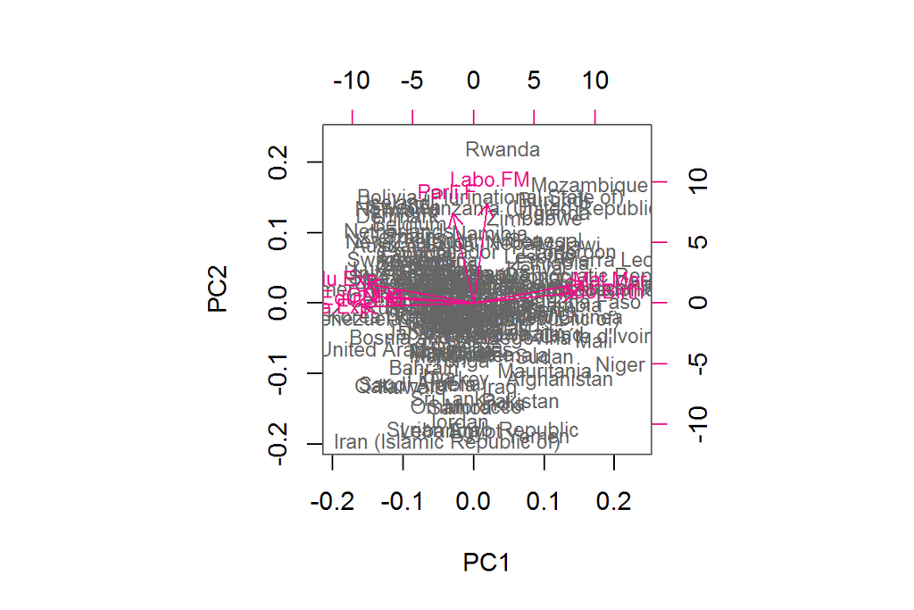

```r
human_scaled <- scale(human)
pca_human_scaled <- prcomp(human_scaled)
biplot(pca_human_scaled, choices = 1:2, cex = c(0.8, .8),
       col = c("grey40", "deeppink2"))
```

Now this biplot seems to show more variation. The reason for this is, that when the variables were not scaled, many of them were not in comparable scales. For example, the ratios were mostly values between 0 and 1. The GNI in contrast varies from 581 to 123124, explaining its role in the unscaled analysis. So the variances are very different too. When the values are standardized, this problem is removed.

The plot shows that most western countries, as well as the majority of Asian countries are clumped to gether in the centre and on the left. Circling the clump containing most of the countries are several Middle-Eastern countries as well as countries from Sub-Saharan Africa, with some others, such as Bolivia. The variables impacting the spread, signified by the arrows show that the majority cluster (to use such an expression) is defined by Life Expectancy, Education and Wealth, where as the variables drawing countries to the right of the plot are Maternal Mortality and Adolescent Birth Rate and the variables drawing countries to the upper part are the Ratio of Women in Parliament as well as the rate of women’s participation in the labour force. The lower part of the plot, containing many countries, has no arrows pointing there.

## Tea

The tea dataset concerns the habits surrounding the consumption of tea, a popular beverage of Asian origin. It contains answers from 300 interviewees on 36 variables relating to their relationship to tea and some variables containing background information. I have chosen six variables concerning basic preferences in consumption of tea. Here are some visualizations of the data:

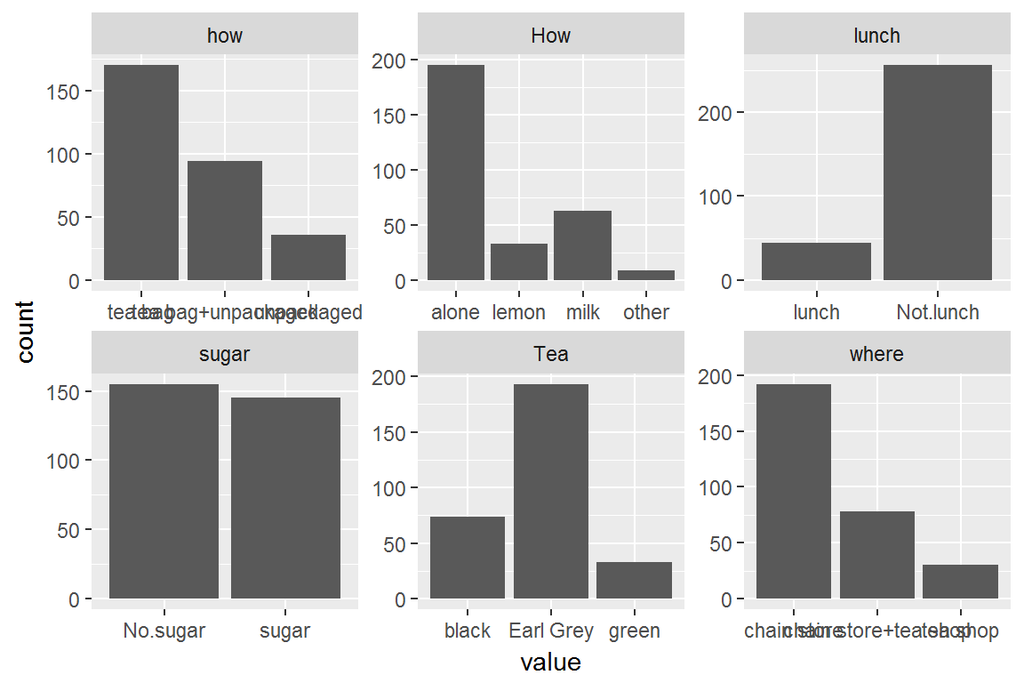

```r
data(tea)
keep_columns <- c("Tea", "How", "how", "sugar", "where", "lunch")
tea_time <- select(tea, one_of(keep_columns))
gather(tea_time) %>% ggplot(aes(value), theme(axis.text.x = element_text(angle = 45, hjust = 1, size = 8))) + facet_wrap("key", scales = "free") + geom_bar()
```

Now a multivariate correspondence analysis of The variables of the dataset:

```r
mca <- MCA(tea_time, graph = FALSE)
summary(mca)
```

```
##
## Call:
## MCA(X = tea_time, graph = FALSE)
##
##
## Eigenvalues
##                        Dim.1   Dim.2   Dim.3   Dim.4   Dim.5   Dim.6
## Variance               0.279   0.261   0.219   0.189   0.177   0.156
## % of var.             15.238  14.232  11.964  10.333   9.667   8.519
## Cumulative % of var.  15.238  29.471  41.435  51.768  61.434  69.953
##                        Dim.7   Dim.8   Dim.9  Dim.10  Dim.11
## Variance               0.144   0.141   0.117   0.087   0.062
## % of var.              7.841   7.705   6.392   4.724   3.385
## Cumulative % of var.  77.794  85.500  91.891  96.615 100.000
##
## Individuals (the 10 first)
##                       Dim.1    ctr   cos2    Dim.2    ctr   cos2    Dim.3
## 1                  | -0.298  0.106  0.086 | -0.328  0.137  0.105 | -0.327
## 2                  | -0.237  0.067  0.036 | -0.136  0.024  0.012 | -0.695
## 3                  | -0.369  0.162  0.231 | -0.300  0.115  0.153 | -0.202
## 4                  | -0.530  0.335  0.460 | -0.318  0.129  0.166 |  0.211
## 5                  | -0.369  0.162  0.231 | -0.300  0.115  0.153 | -0.202
## 6                  | -0.369  0.162  0.231 | -0.300  0.115  0.153 | -0.202
## 7                  | -0.369  0.162  0.231 | -0.300  0.115  0.153 | -0.202
## 8                  | -0.237  0.067  0.036 | -0.136  0.024  0.012 | -0.695
## 9                  |  0.143  0.024  0.012 |  0.871  0.969  0.435 | -0.067
## 10                 |  0.476  0.271  0.140 |  0.687  0.604  0.291 | -0.650
##                       ctr   cos2
## 1                   0.163  0.104 |
## 2                   0.735  0.314 |
## 3                   0.062  0.069 |
## 4                   0.068  0.073 |
## 5                   0.062  0.069 |
## 6                   0.062  0.069 |
## 7                   0.062  0.069 |
## 8                   0.735  0.314 |
## 9                   0.007  0.003 |
## 10                  0.643  0.261 |
##
## Categories (the 10 first)
```

[output cut: 16 more lines]

```
## lemon                0.035   3.226 |   1.329  14.771   0.218   8.081 |
## milk                 0.020   2.422 |   0.013   0.003   0.000   0.116 |
## other                0.102   5.534 |  -2.524  14.526   0.197  -7.676 |
## tea bag              0.161  -6.941 |  -0.065   0.183   0.006  -1.287 |
## tea bag+unpackaged   0.478  11.956 |   0.019   0.009   0.000   0.226 |
## unpackaged           0.141  -6.482 |   0.257   0.602   0.009   1.640 |
##
## Categorical variables (eta2)
##                      Dim.1 Dim.2 Dim.3
## Tea                | 0.126 0.108 0.410 |
## How                | 0.076 0.190 0.394 |
## how                | 0.708 0.522 0.010 |
## sugar              | 0.065 0.001 0.336 |
## where              | 0.702 0.681 0.055 |
## lunch              | 0.000 0.064 0.111 |
```

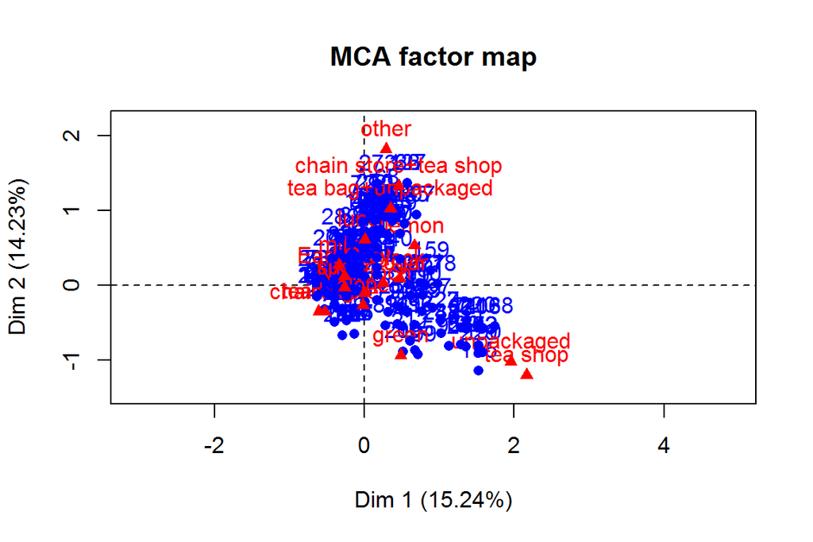

```r
plot(mca, invisible=c("quali.sup"))
```

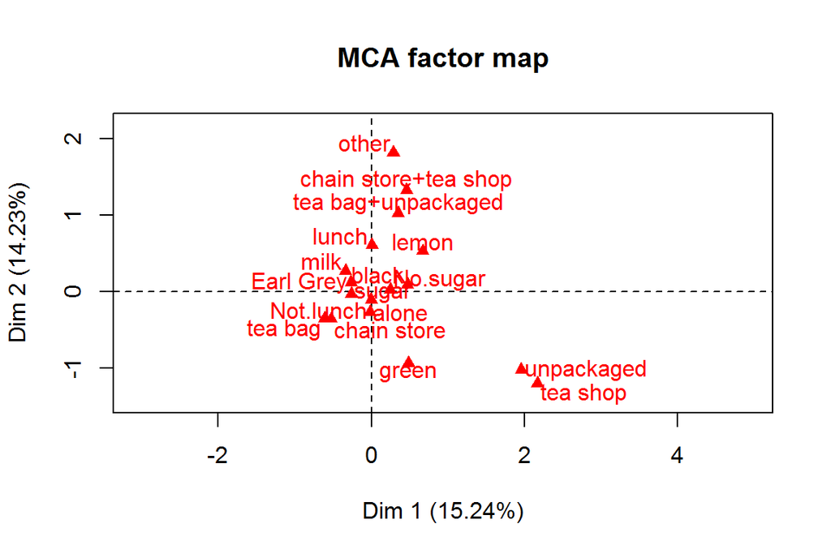

```r
plot(mca, invisible=c("ind"))
```

From this we can see, that the basic preferences between interviewees is clumped together quite closely, but when we observe the variables alone, we can see that such choices as whether Earl Grey -mix is used or whether one wants their tea black or sweet or lemony are the variables forming the cluster at the centre. Choices that can be seen as more sophisticated, such as the use of a tea shop and unpackaged tea are quite diffrentiated. This suggests that while the basic consumption patterns are factored closely together, the prefernce for example a tea shop and unpackaged tea are related.